# EDA Activity 4

Motoki Sugino

10/21/2016

### Exercises

(These problems are exercises 24a and 24b from Tukey (1977).)

### For tukey.24a

Straightening for tukey.24a

```r
library(LearnEDA)
#slider.straighten(tukey.24a$index,tukey.24a$temp) power x = 0.4 , power y = 0.2
```

```r
fit <- rline(tukey.24a$index,tukey.24a$temp)
half.slope.ratio(fit$spoints.x, fit$spoints.y, 1, 1)
```

```
## [1] 0.9676214
```

```r
half.slope.ratio(fit$spoints.x, fit$spoints.y, 0.4, 0.2)
```

```
## [1] 0.999774
```

To see if this choice of reexpression works, we inspect the scatterplot of the transformed data.

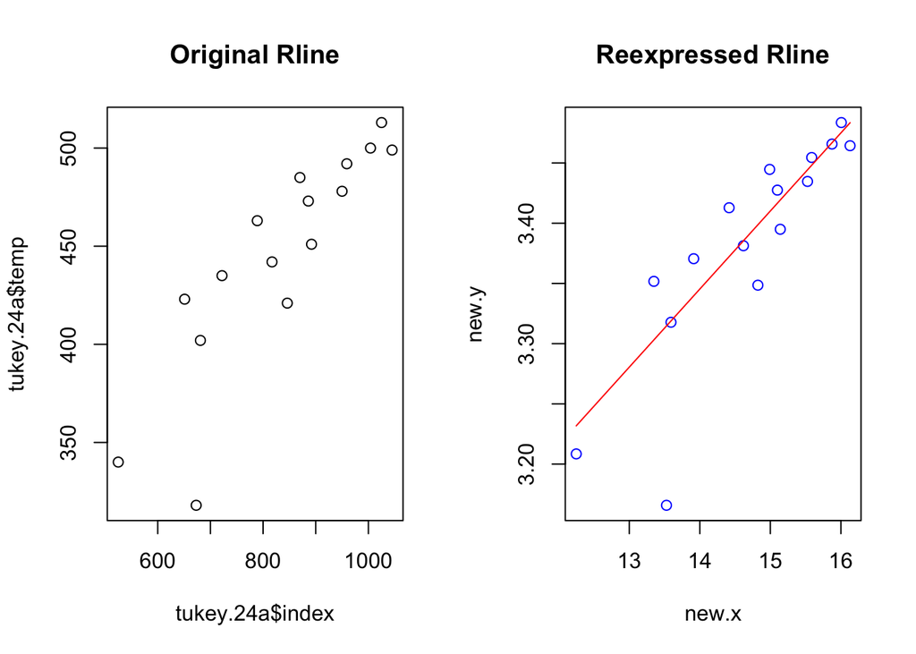

```r
### scatterplot ###
# original data #
par(mfrow=c(1,2))
myfit <- rline(tukey.24a$index, tukey.24a$temp, iter=5)
plot(tukey.24a$index, tukey.24a$temp,main = "Original Rline")
curve(717.3+0.3034*x, add=TRUE, col="red")

# reexpressed data #
new.x <- tukey.24a$index ^ (0.4)
new.y <- tukey.24a$temp ^ (0.2)
plot(new.x, new.y, col="blue", main = "Reexpressed Rline")
curve(2.438+0.06481*x,add=TRUE, col="red")
```

```r
fit <- rline(new.x, new.y, iter=5)
c(fit$a, fit$b, fit$xC) #FIT <- with(myfit, a + b * (x - xC))
```

```
## [1]  3.40451064  0.06480972 14.90681014
```

```r
par(mfrow=c(1,1))
```

From the both scatterplots, we cannot see the big difference.

We see that the summary points are $(673, 402), (858, 457), (1004, 499)$.

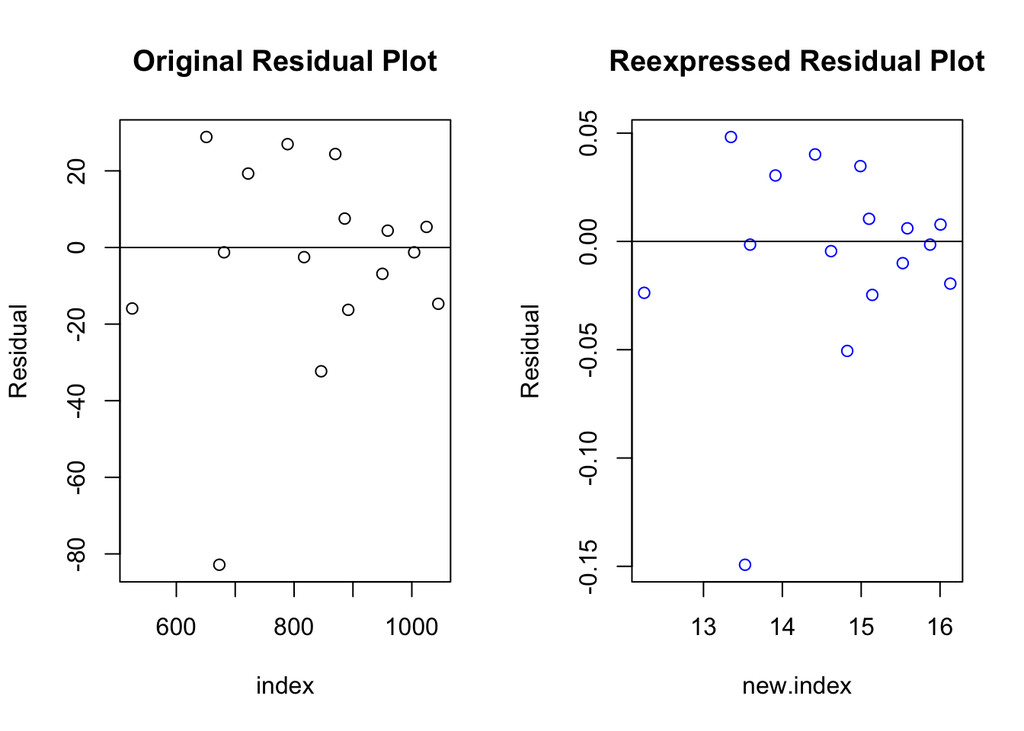

```r
### residual plot ###
# original data #
par(mfrow=c(1,2))
plot(tukey.24a$index, myfit$residual, ylab="Residual",xlab="index", main = "Original Residual Plot")#The residuals from this line fit are shown below.#
abline(h=0)

# reexpressed data #
plot(new.x, fit$residual, ylab="Residual",xlab="new.index",col="blue",main = "Reexpressed Residual Plot")#The residuals from this line fit are shown below.#
abline(h=0)
```

From the residual plots, we can slightly see that the residuals in the reexpressed data are more constant and closer to the zero line.

### For tukey.24b

```r
fit=rline(tukey.24b$diameter,tukey.24b$stretch)
half.slope.ratio(fit$spoints.x,fit$spoints.y,1,1)
```

```
## [1] 0.3915395
```

The half-slope ratio is $0.3915$, indicating substantial curvature in the plot.

```r
half.slope.ratio(fit$spoints.x,fit$spoints.y,0.5,1.1)
```

```
## [1] 0.9934572
```

To see if this choice of reexpression works, we inspect the scatterplot of the transformed data.

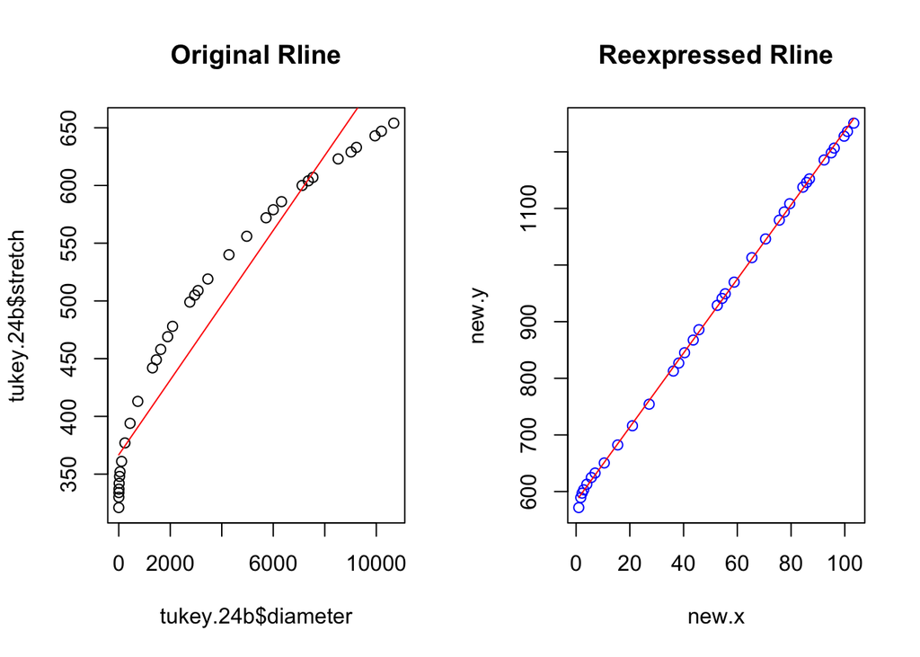

```r
### scatterplot ###
# original data #
par(mfrow=c(1,2))
myfit <- rline(tukey.24b$diameter,tukey.24b$stretch, iter=5)
plot(tukey.24b$diameter,tukey.24b$stretch, main = "Original Rline")
curve(366.7+0.0324*x, add=TRUE, col="red")

# reexpressed data #
new.x <- tukey.24b$diameter ^ (0.5)
new.y <- tukey.24b$stretch ^ (1.1)
plot(new.x, new.y, col="blue", main = "Reexpressed Rline")
curve(583+6.54*x,add=TRUE, col="red")
```

```r
fit <- rline(new.x, new.y, iter=5)
c(fit$a, fit$b, fit$xC) #FIT <- with(myfit, a + b * (x - xC))
```

```
## [1] 932.378006   6.540065  53.424802
```

```r
par(mfrow=c(1,1))
```

From the both scatterplots, we can see the big difference so we are successful to see the liner relationship.

We see that the summary points are $(32, 348), (2855, 502), (8520, 623)$.

For original data : We fit a line shown below – it has intercept **459.2**, slope **0.0324**, and xC = **2855**. Our line fit is : $stretch = 459.2 +0.0324*(diameter - (2855) )$

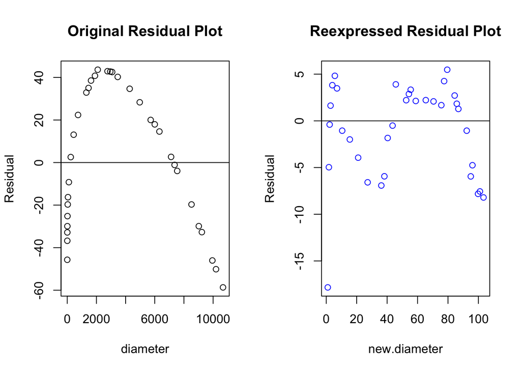

```r
### residual plot ###
# original data #
par(mfrow=c(1,2))
plot(tukey.24b$diameter, myfit$residual, ylab="Residual",xlab="diameter", main = "Original Residual Plot")#The residuals from this line fit are shown below.#
abline(h=0)

# reexpressed data #
plot(new.x, fit$residual, ylab="Residual",xlab="new.diameter",col="blue",main = "Reexpressed Residual Plot")#The residuals from this line fit are shown below.#
abline(h=0)
```

We can see that the residual plot looks better after eexpressing the data.

The residuals is successful in straightening the association pattern in the graph. There might be one unusual observation, which is diameter 1,in the left bottom in the rexpressed residual plot.